# ANALYSIS REPORT

Ambroise

13 décembre, 2021

### Setup

```r
library(repro)
# load packages from yaml header
automate_load_packages()
# include external scripts
automate_load_scripts()

# load data
data_ambroise_full  <- automate_load_data(data_ambroise_full, read_sav)



sessio = sessionInfo(); #opts_chunk$set(echo = F, message=F, warning=F) # set echo F for all
```

This file was automatically created via `the Repro package (version 0.1.0)` using R version 4.0.1 (2020-06-06)

```r
options(scipen = 666, warn=-1, contrasts=c("contr.sum","contr.poly"), knitr.kable.NA = '')  #remove scientific notation # remove warnings #set contrasts to sum !
set.seed(666) #set random seed

# panderOptions('knitr.auto.asis', FALSE) #remove auto styling

# Look at R/clean.R (listed in the YAML) which does all the preprocessing for more info


# If you are unsure weather or not you have `git` `make` & `docker`.
# check_git()
# check_make()
# check_docker()
```

### Introduction

#### Demographics

```r
base[c("Age", "Gender", "Profession")] %>%  tbl_summary(statistic = list(all_continuous() ~ "{mean} ({sd})", all_categorical() ~ "{n} / {N} ({p}%)"),)  %>% modify_caption("**Table 1. Demographics **") %>%
  bold_labels()
```

**Table 1. Demographics **

| **Characteristic** | **N = 303**<sup>1</sup> |
| --- | --- |
| Age | 21.7 (4.4) |
| Gender |  |
| Homme | 56 / 303 (18%) |
| Femme | 244 / 303 (81%) |
| Autre/NA | 3 / 303 (1.0%) |
| Profession |  |
| Etudiant.e | 298 / 303 (98%) |
| Actif.ve | 3 / 303 (1.0%) |
| Les deux | 2 / 303 (0.7%) |

<sup>*1*</sup> Mean (SD); n / N (%)

$~$ $~$

### Statistics

$~$ $~$

##### Correlation

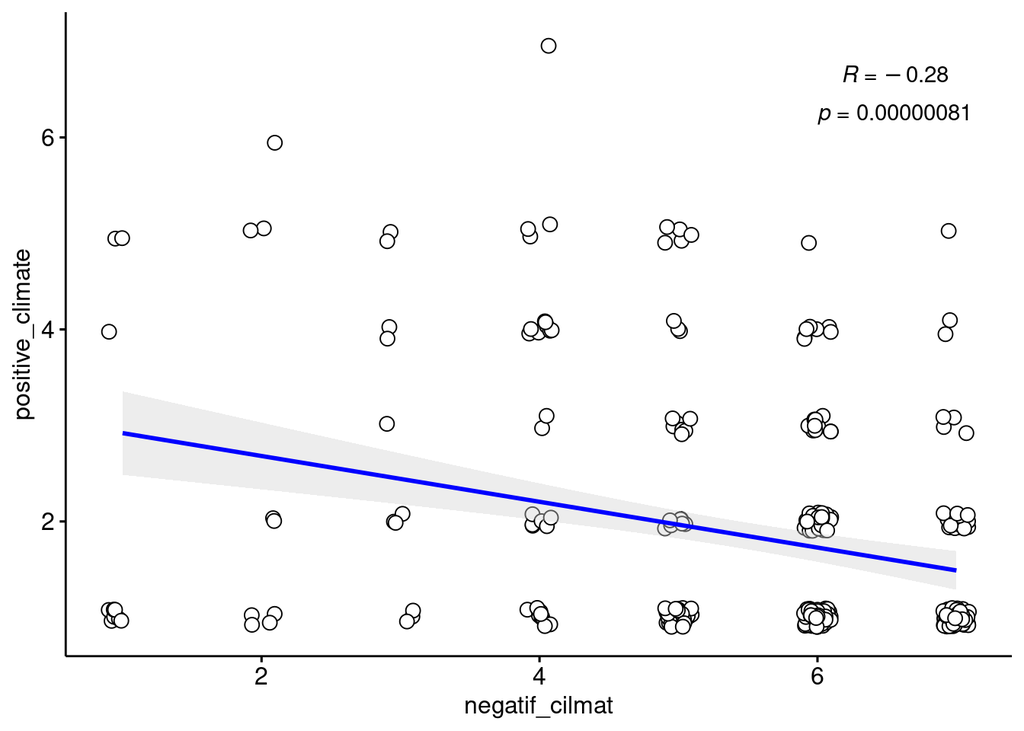

$~$ $~$

#### Price

```r
base_price = base_clean #no huge outliers, see appendix

final_price = lm(Price ~ Priming*Product+ Behav_enviro + Age,  data = base_price)

apa_lm <- apa_print(anova(final_price))
apa_table(apa_lm$table,  caption = "Anova table for Price.")
```

(#tab:lm Price)

*Anova table for Price.*

| Effect | $F$ | $\mathit{df}_1$ | $\mathit{df}_2$ | $\mathit{MSE}$ | $p$ | $\hat{\eta}^2_G$ |
| --- | --- | --- | --- | --- | --- | --- |
| Priming | 0.36 | 1 | 290 | 5.46 | .549 | .001 |
| Product | 2.75 | 1 | 290 | 5.46 | .098 | .009 |
| Behav enviro | 7.28 | 1 | 290 | 5.46 | .007 | .024 |
| Age | 2.93 | 1 | 290 | 5.46 | .088 | .010 |
| Priming $\times$ Product | 2.36 | 1 | 290 | 5.46 | .125 | .008 |

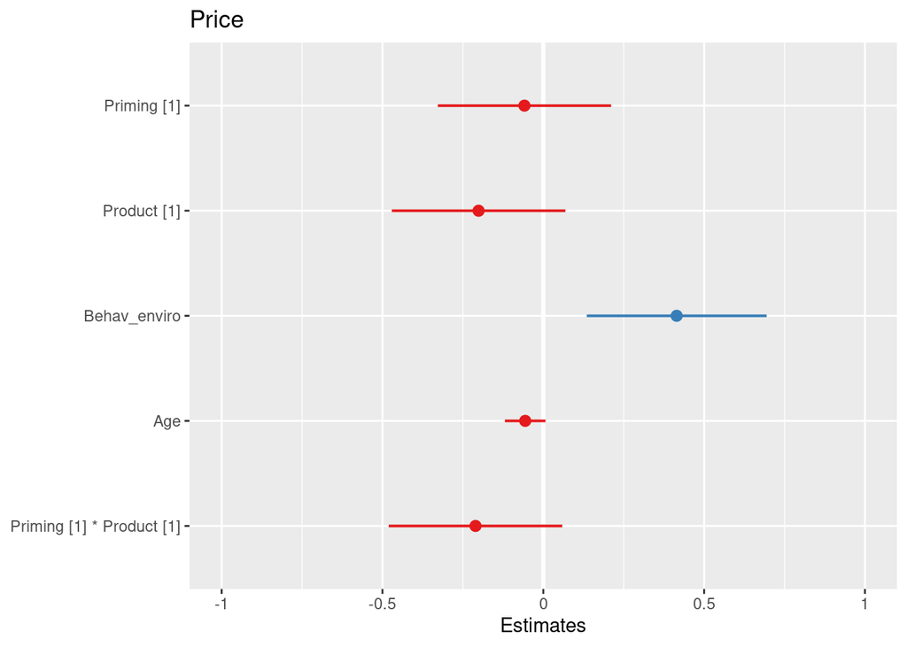

```r
plot_model(final_price)
```

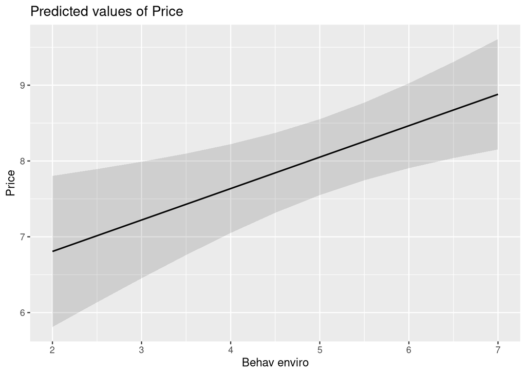

```r
sjPlot::plot_model(final_price, type = "pred")[3]
```

$~$ $~$

#### Probability to buy

```r
base_buy = filter(base_clean, id %notin% c("13804")) #remove huge outliers, see appendix


final_buy = lm(Buy ~ Priming*Product + Behav_enviro + Age,  data = base_buy)

apa_lm <- apa_print(anova(final_buy))
apa_table(apa_lm$table,  caption = "Anova table for Probability to buy.")
```

(#tab:lm Buy)

*Anova table for Probability to buy.*

| Effect | $F$ | $\mathit{df}_1$ | $\mathit{df}_2$ | $\mathit{MSE}$ | $p$ | $\hat{\eta}^2_G$ |
| --- | --- | --- | --- | --- | --- | --- |
| Priming | 0.06 | 1 | 289 | 2.05 | .805 | .000 |
| Product | 11.40 | 1 | 289 | 2.05 | .001 | .038 |
| Behav enviro | 12.43 | 1 | 289 | 2.05 | < .001 | .041 |
| Age | 8.17 | 1 | 289 | 2.05 | .005 | .027 |
| Priming $\times$ Product | 0.20 | 1 | 289 | 2.05 | .654 | .001 |

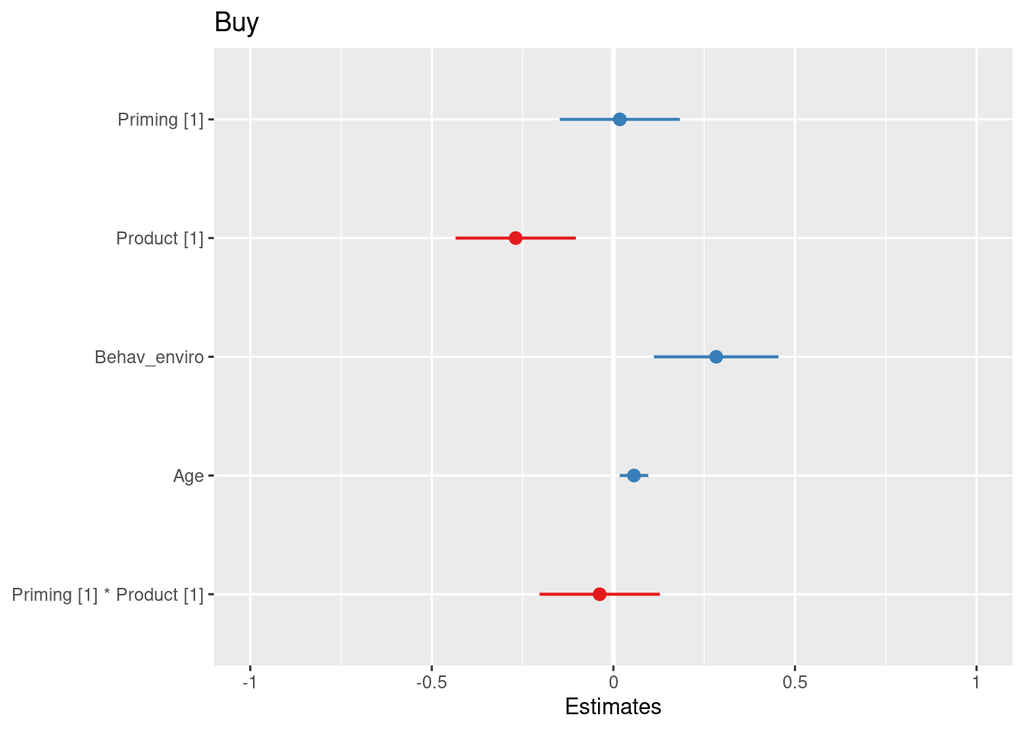

```r
sjPlot::plot_model(final_buy)
```

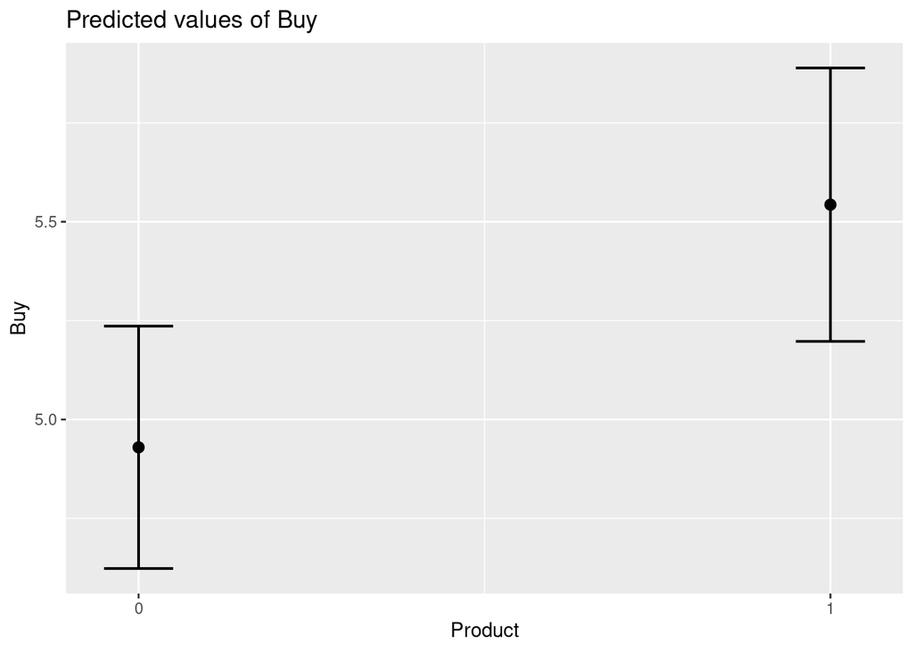

```r
sjPlot::plot_model(final_buy, type = "pred")[2]
```

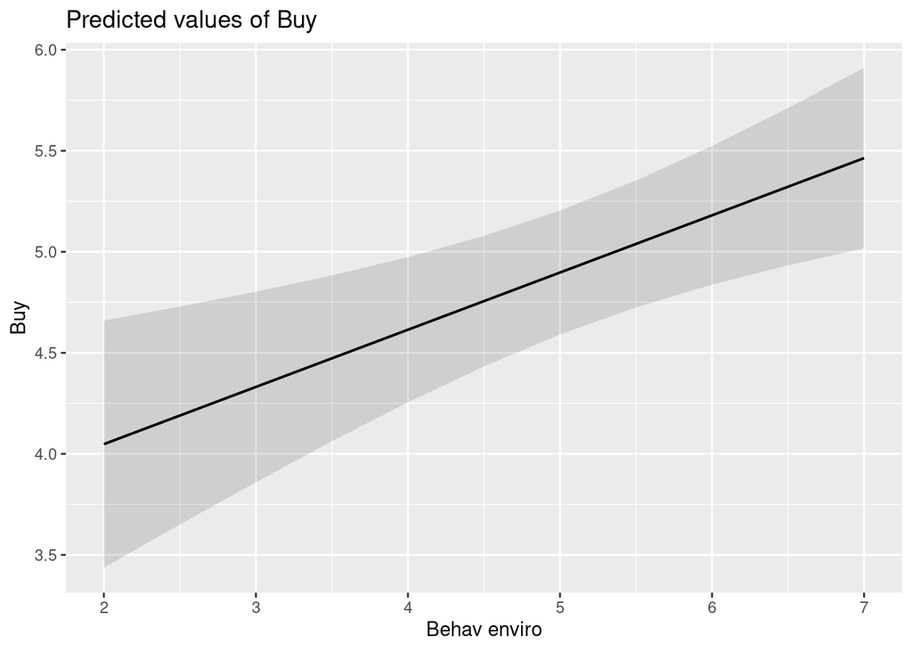

```r
sjPlot::plot_model(final_buy, type = "pred")[3]
```

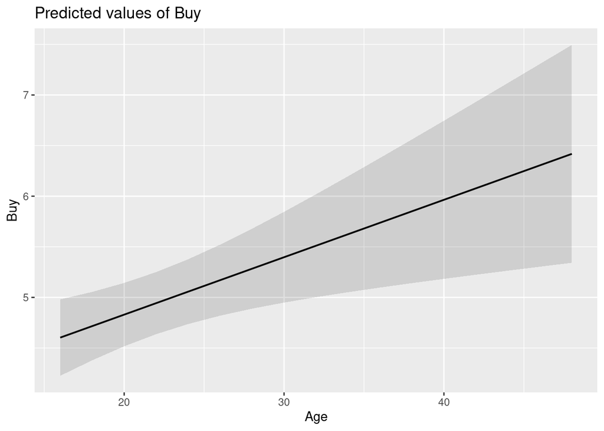

```r
sjPlot::plot_model(final_buy, type = "pred")[4]
```

$~$ $~$

#### Reccomendation

```r
base_recco = base_clean #no huge outliers, see appendix

final_recco = lm(Reccomend ~ Priming*Product+Product*Behav_enviro + Age + Gender,  data = base_recco)

apa_lm <- apa_print(anova(final_recco))
apa_table(apa_lm$table,  caption = "Anova table for Reccomendation.")
```

(#tab:lm Recco)

*Anova table for Reccomendation.*

| Effect | $F$ | $\mathit{df}_1$ | $\mathit{df}_2$ | $\mathit{MSE}$ | $p$ | $\hat{\eta}^2_G$ |
| --- | --- | --- | --- | --- | --- | --- |
| Priming | 0.51 | 1 | 286 | 2.44 | .477 | .002 |
| Product | 28.91 | 1 | 286 | 2.44 | < .001 | .092 |
| Behav enviro | 33.63 | 1 | 286 | 2.44 | < .001 | .105 |
| Age | 0.99 | 1 | 286 | 2.44 | .320 | .003 |
| Gender | 1.12 | 1 | 286 | 2.44 | .291 | .004 |
| Priming $\times$ Product | 0.11 | 1 | 286 | 2.44 | .743 | .000 |
| Product $\times$ Behav enviro | 5.24 | 1 | 286 | 2.44 | .023 | .018 |

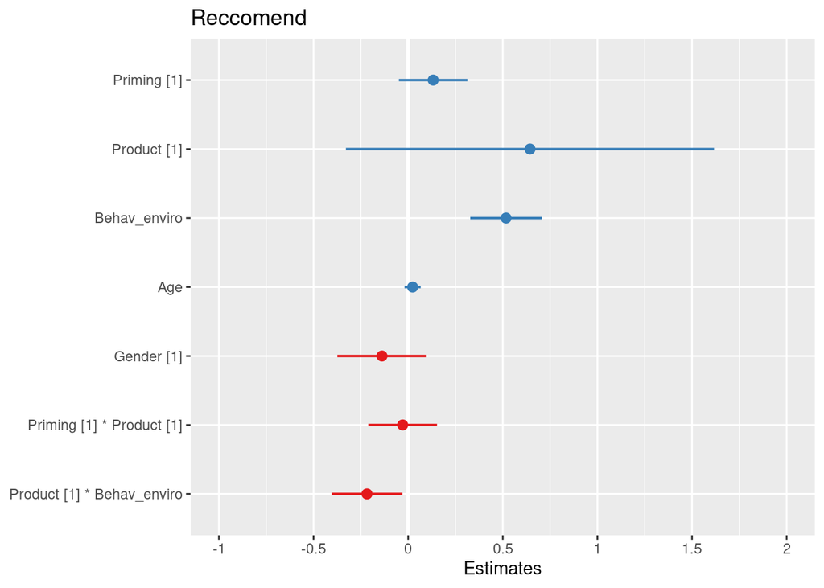

```r
sjPlot::plot_model(final_recco)
```

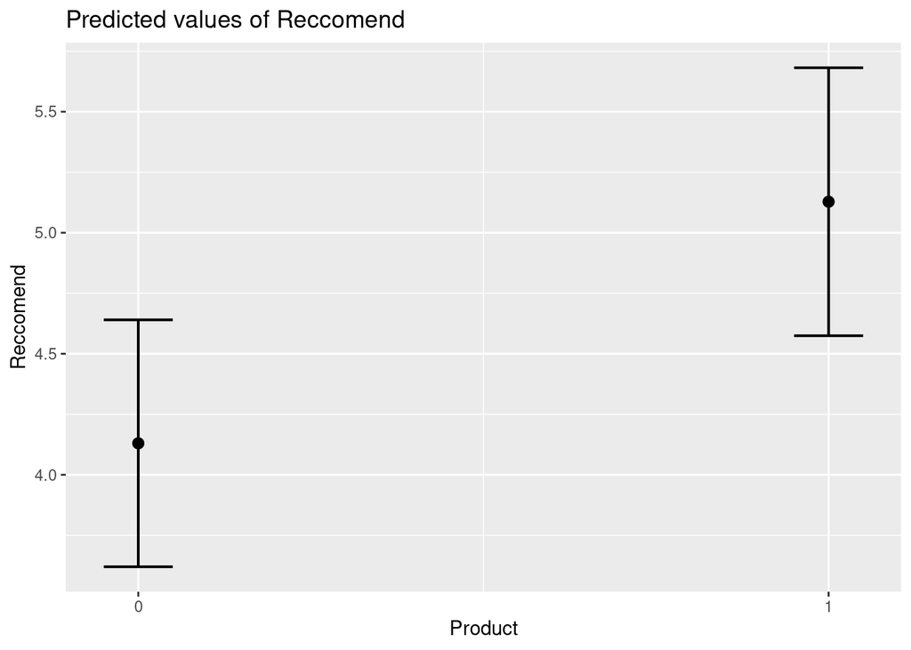

```r
sjPlot::plot_model(final_recco, type = "pred")[2]
```

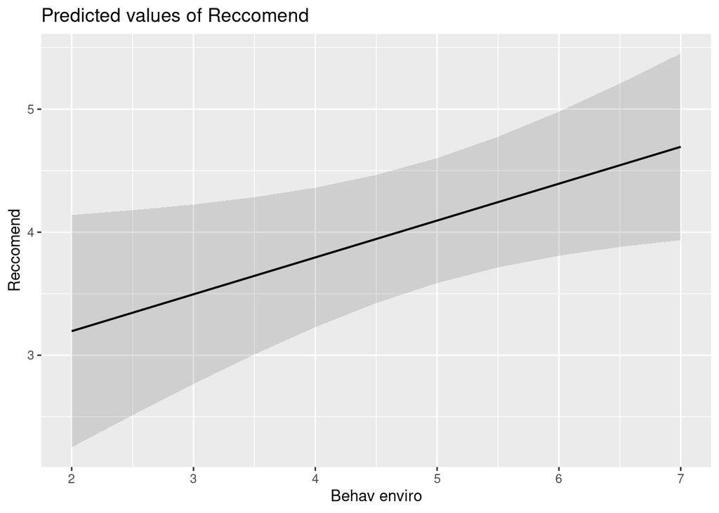

```r
sjPlot::plot_model(final_recco, type = "pred")[3]
```

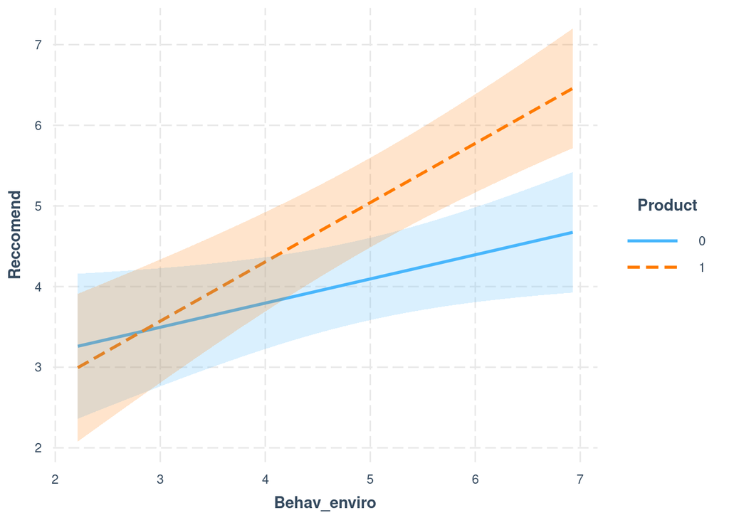

```r
interactions::interact_plot(final_recco, pred = Behav_enviro, modx = Product, interval = TRUE)
```

Example for reporting :

Product ($F(1, 286) = 28.91$, $\mathit{MSE} = 2.44$, $p < .001$, $\hat{\eta}^2_G = .092$) and Behav_enviro ($F(1, 286) = 33.63$, $\mathit{MSE} = 2.44$, $p < .001$, $\hat{\eta}^2_G = .105$) affected reccomendation. However, the effect of Behav_enviro differed by Product, $F(1, 286) = 5.24$, $\mathit{MSE} = 2.44$, $p = .023$, $\hat{\eta}^2_G = .018$.

$~$ $~$

#### Ecologic Evaluation

```r
base_eco = filter(base_clean, id %notin% c("13594", "11200", "13804", "12529", "11017")) #remove huge outliers, see appendix

final_eco = lm(Ecolo_Eval ~ Priming*Product+Behav_enviro + Age + Gender,  data = base_eco)

apa_lm <- apa_print(anova(final_eco))
apa_table(apa_lm$table, caption = "Anova table for Reccomendation.")
```

(#tab:lm Ecolo_Eval)

| Effect | $F$ | $\mathit{df}_1$ | $\mathit{df}_2$ | $\mathit{MSE}$ | $p$ | $\hat{\eta}^2_G$ |
| --- | --- | --- | --- | --- | --- | --- |
| Priming | 0.05 | 1 | 282 | 1.18 | .832 | .000 |
| Product | 76.73 | 1 | 282 | 1.18 | < .001 | .214 |
| Behav enviro | 6.41 | 1 | 282 | 1.18 | .012 | .022 |
| Age | 0.23 | 1 | 282 | 1.18 | .629 | .001 |
| Gender | 0.09 | 1 | 282 | 1.18 | .762 | .000 |
| Priming $\times$ Product | 1.33 | 1 | 282 | 1.18 | .250 | .005 |

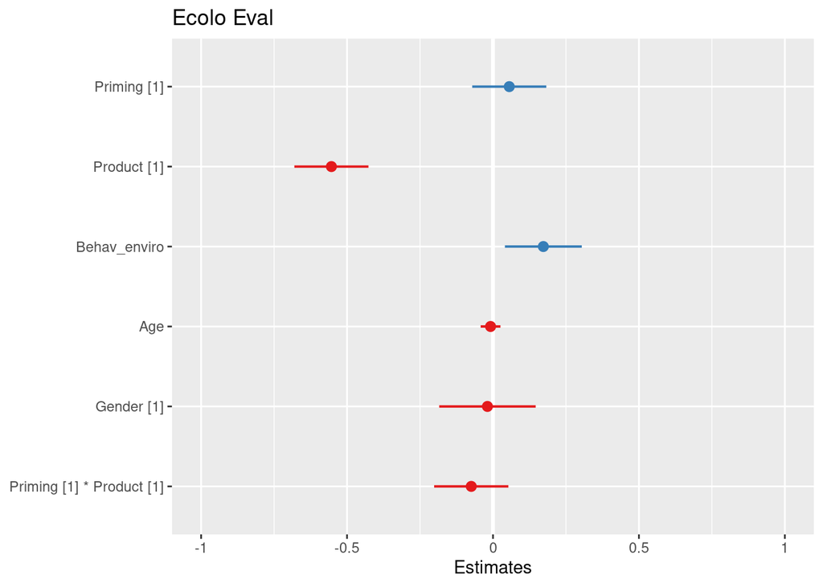

```r
sjPlot::plot_model(final_eco)
```

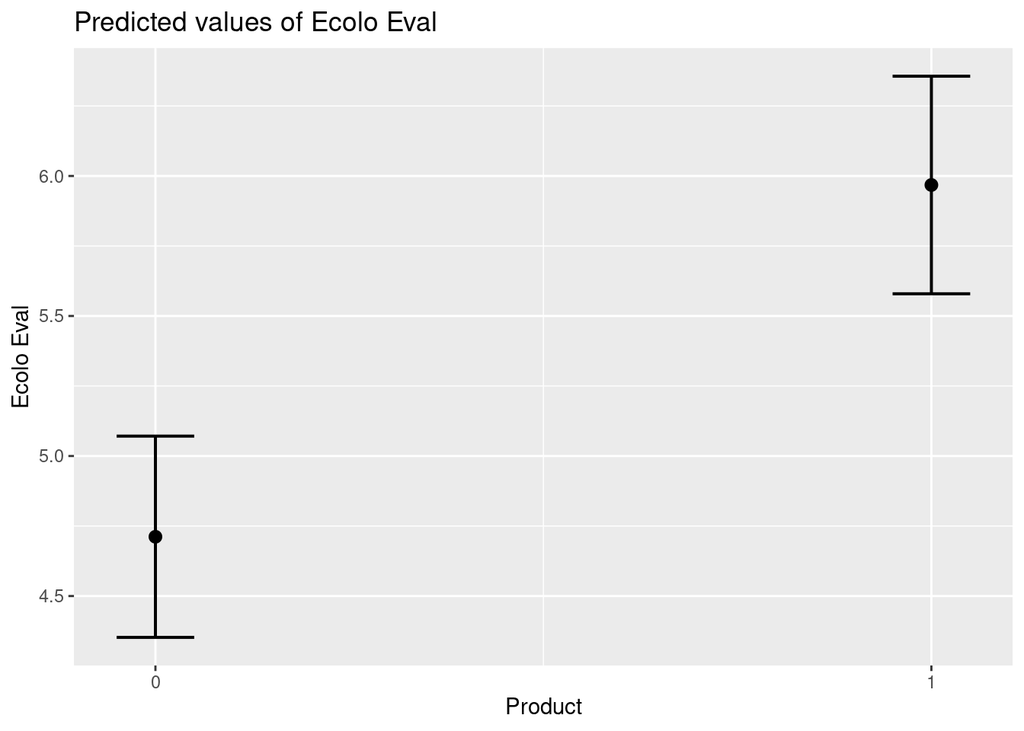

```r
sjPlot::plot_model(final_eco, type = "pred")[2]
```

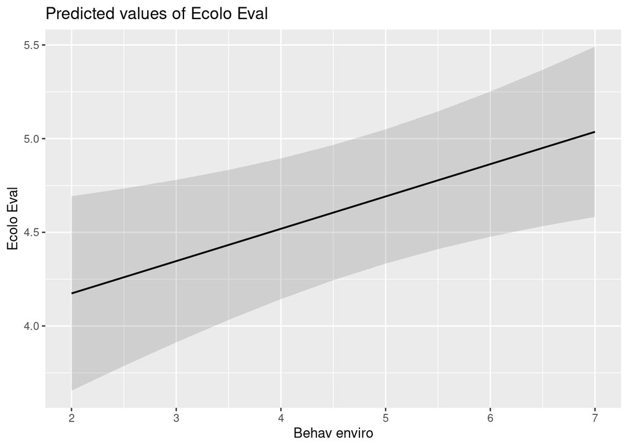

```r
sjPlot::plot_model(final_eco, type = "pred")[3]
```

$~$ $~$

### Appendix

$~$ $~$

#### Visual check normality

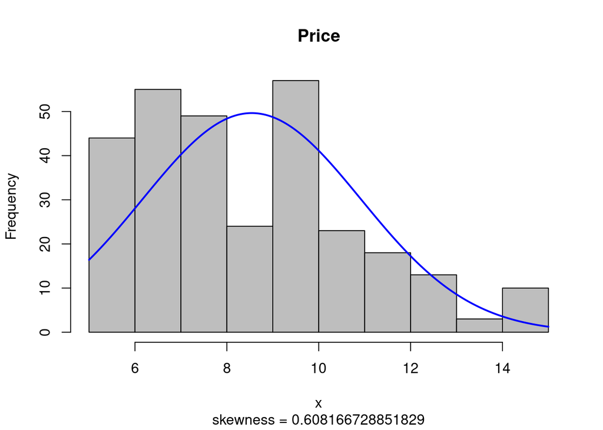

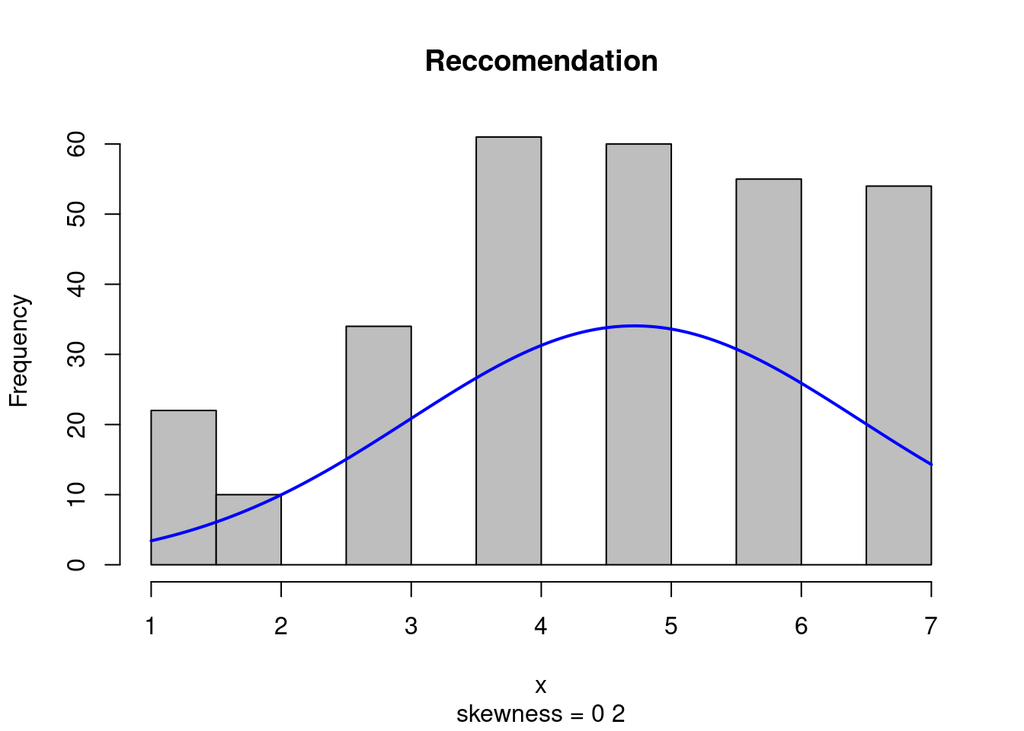

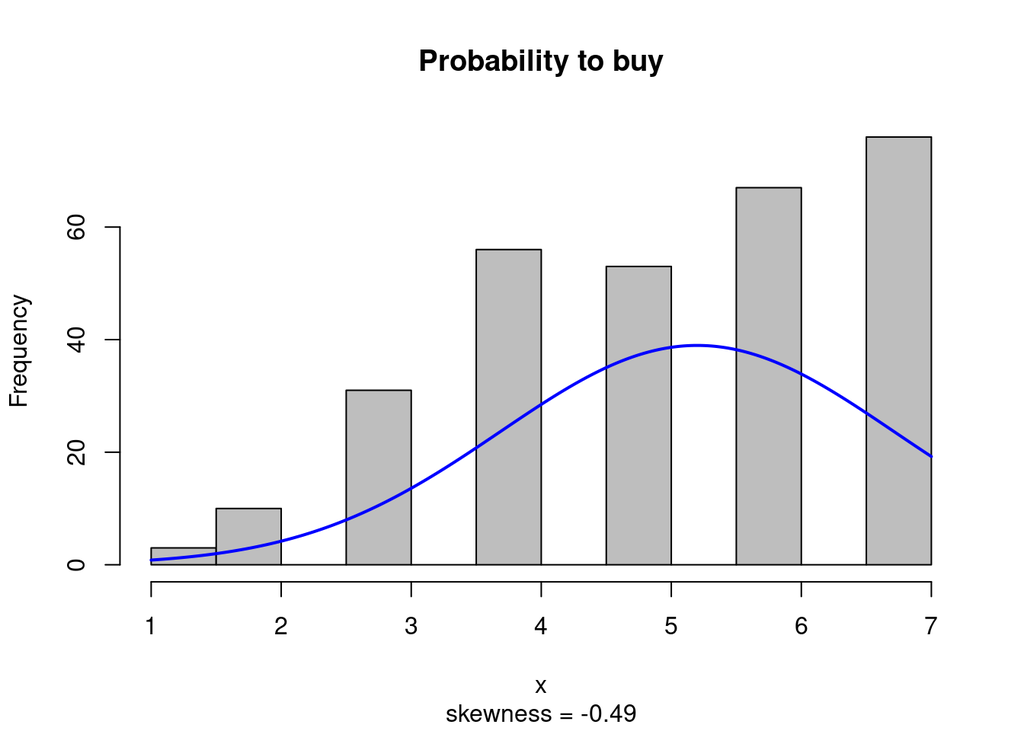

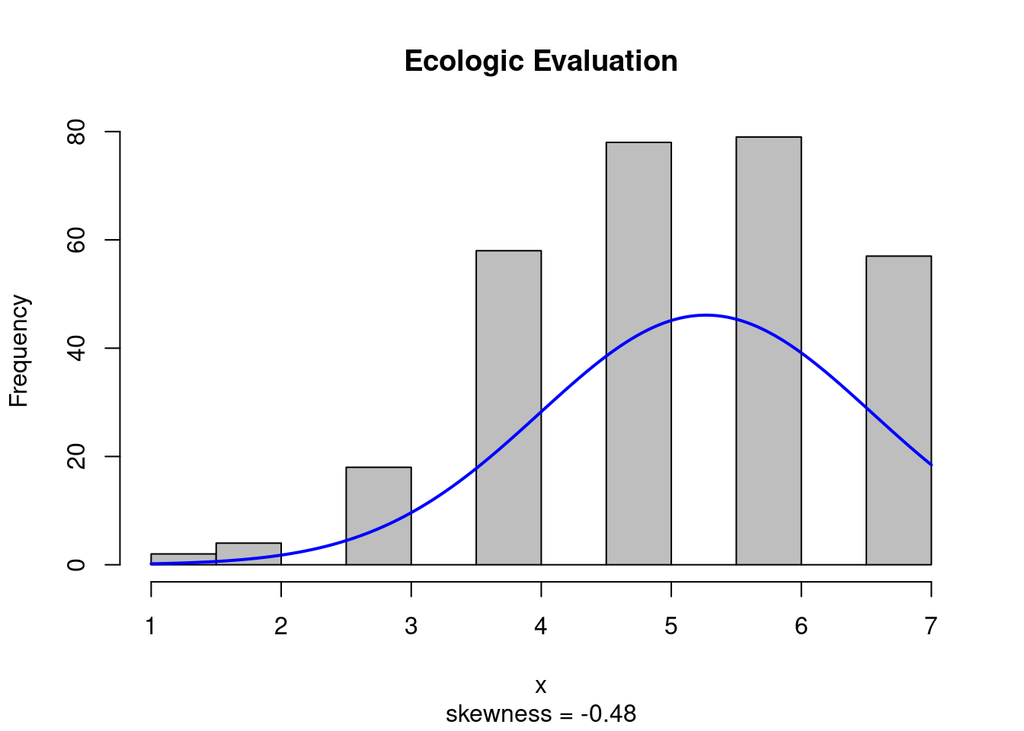

```r
plotNormalHistogram(base_clean$Price, main = "Price", sub = paste("skewness =", skewness(base_clean$Price, na.rm = TRUE)))


# print("Check price density by product")
# densityPlot(base_clean$Price, g = base_clean$Product) # by product

plotNormalHistogram(base_clean$Reccomend, main = "Reccomendation", sub = paste("skewness =", round(skewness(base_clean$Reccomend, na.rm = TRUE)),2))



plotNormalHistogram(base_clean$Buy, main = "Probability to buy", sub =
                      paste("skewness =", round(skewness(base_clean$Buy, na.rm = TRUE),2)))


plotNormalHistogram(base_clean$Ecolo_Eval, main = "Ecologic Evaluation", sub =
                      paste("skewness =", round(skewness(base_clean$Ecolo_Eval, na.rm = TRUE),2)))
```

$~$ $~$

#### Model selection for price

| Stepwise Model Path Analysis of Deviance Table |
| --- |
| Initial Model: |
| Price ~ Priming * Product * Behav_enviro + Priming * Product * |
| Decision_mode + Priming * Product * Age |
| Final Model: |
| Price ~ Priming + Product + Behav_enviro + Age + Priming:Product |

Step

Df

Deviance

Resid. Df

Resid. Dev

AIC

276

1565.305

532.9811

- Priming:Product:Decision_mode

2

0.6901684

278

1565.996

529.1116

- Priming:Decision_mode

2

2.3474423

280

1568.343

525.5550

- Product:Decision_mode

2

3.4924163

282

1571.835

522.2134

- Decision_mode

2

5.1740691

284

1577.009

519.1861

- Priming:Product:Behav_enviro

1

0.0190158

285

1577.028

517.1897

- Priming:Behav_enviro

1

0.1376896

286

1577.166

515.2155

- Product:Behav_enviro

1

0.6856872

287

1577.852

513.3442

- Priming:Product:Age

1

2.9959029

288

1580.848

511.9057

- Product:Age

1

0.2266283

289

1581.074

509.9481

- Priming:Age

1

2.6527725

290

1583.727

508.4443

$~$ $~$

#### Price: Diagnostics Plots for linear model

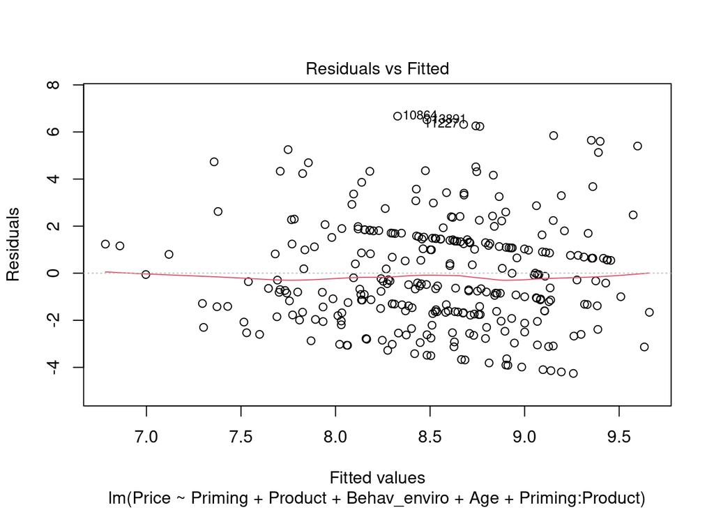

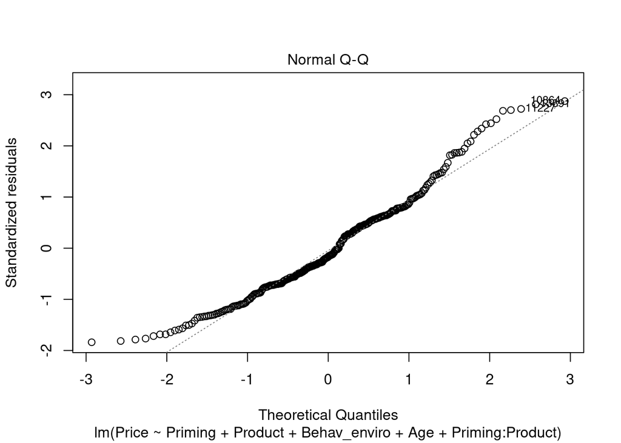

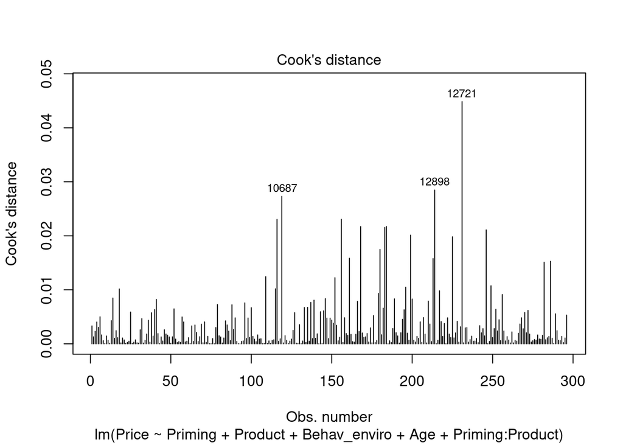

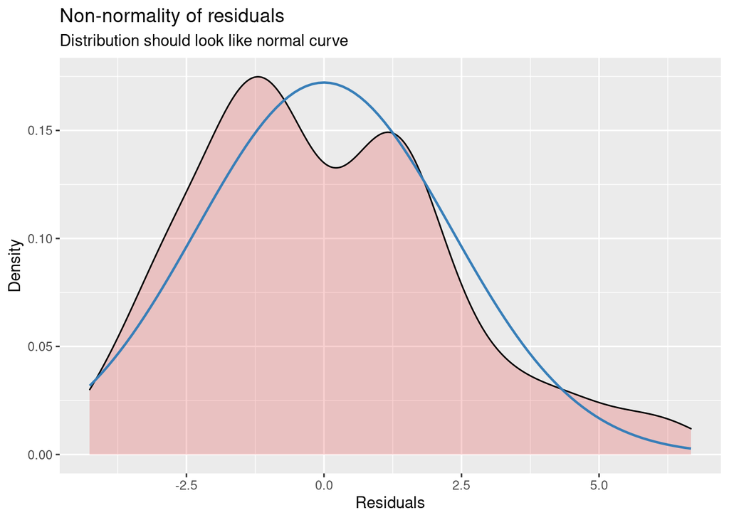

$~$ $~$

#### Model selection for Probality to buy

| Stepwise Model Path Analysis of Deviance Table |
| --- |
| Initial Model: |
| Buy ~ Priming * Product * Behav_enviro + Priming * Product * |
| Decision_mode + Priming * Product * Age |
| Final Model: |
| Buy ~ Product + Behav_enviro + Age + Product:Behav_enviro |

Step

Df

Deviance

Resid. Df

Resid. Dev

AIC

276

581.3937

239.8203

- Priming:Product:Decision_mode

2

0.3804853

278

581.7742

236.0140

- Product:Decision_mode

2

0.2484490

280

582.0227

232.1404

- Priming:Decision_mode

2

3.3128483

282

585.3355

229.8204

- Decision_mode

2

1.5826360

284

586.9181

226.6197

- Priming:Product:Age

1

0.2805508

285

587.1987

224.7611

- Product:Age

1

0.4453666

286

587.6441

222.9855

- Priming:Age

1

0.9580960

287

588.6022

221.4678

- Priming:Product:Behav_enviro

1

3.4230349

288

592.0252

221.1842

- Priming:Product

1

1.1023129

289

593.1275

219.7348

- Priming:Behav_enviro

1

3.2536489

290

596.3812

219.3541

- Priming

1

0.5979355

291

596.9791

217.6507

$~$ $~$

#### Probability to buy: Diagnostics Plots for linear model

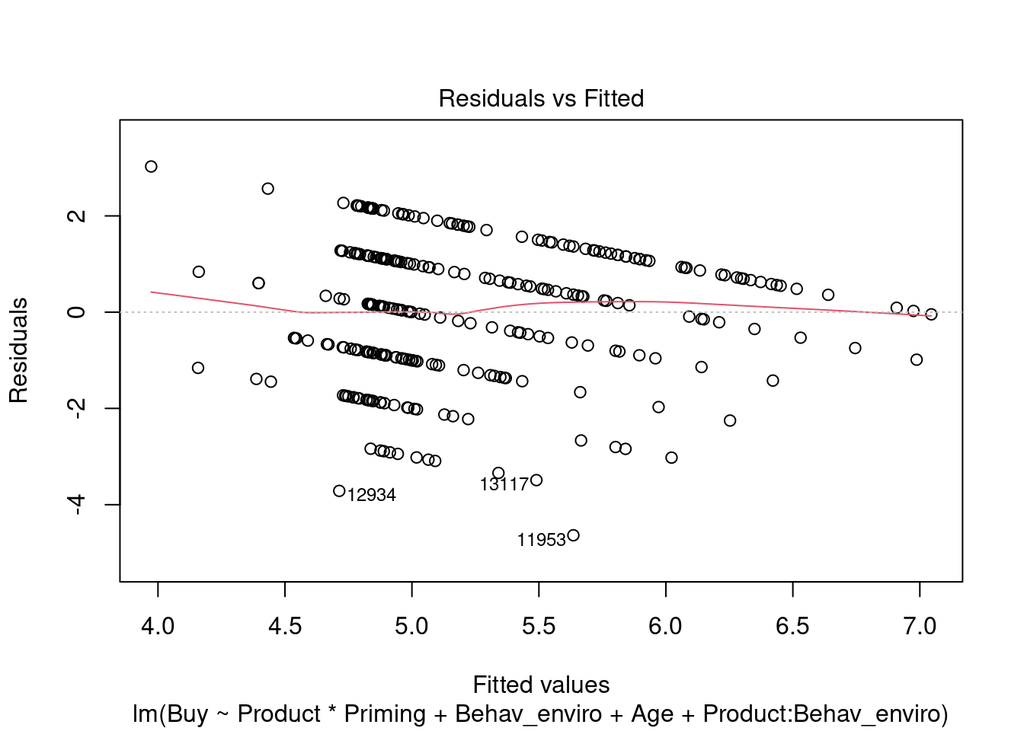

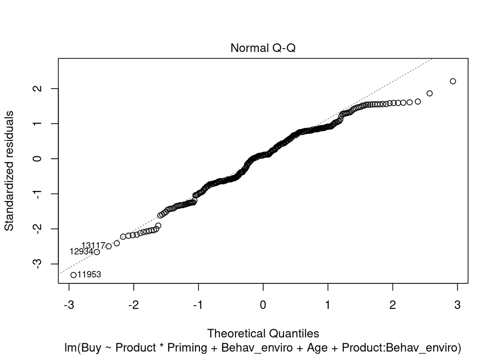

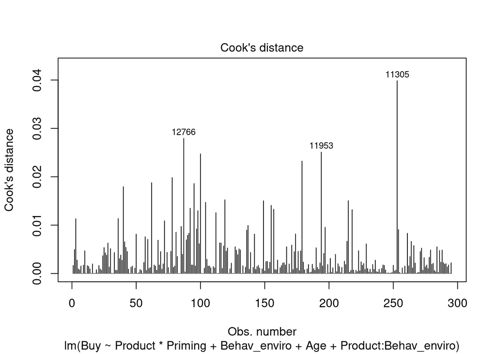

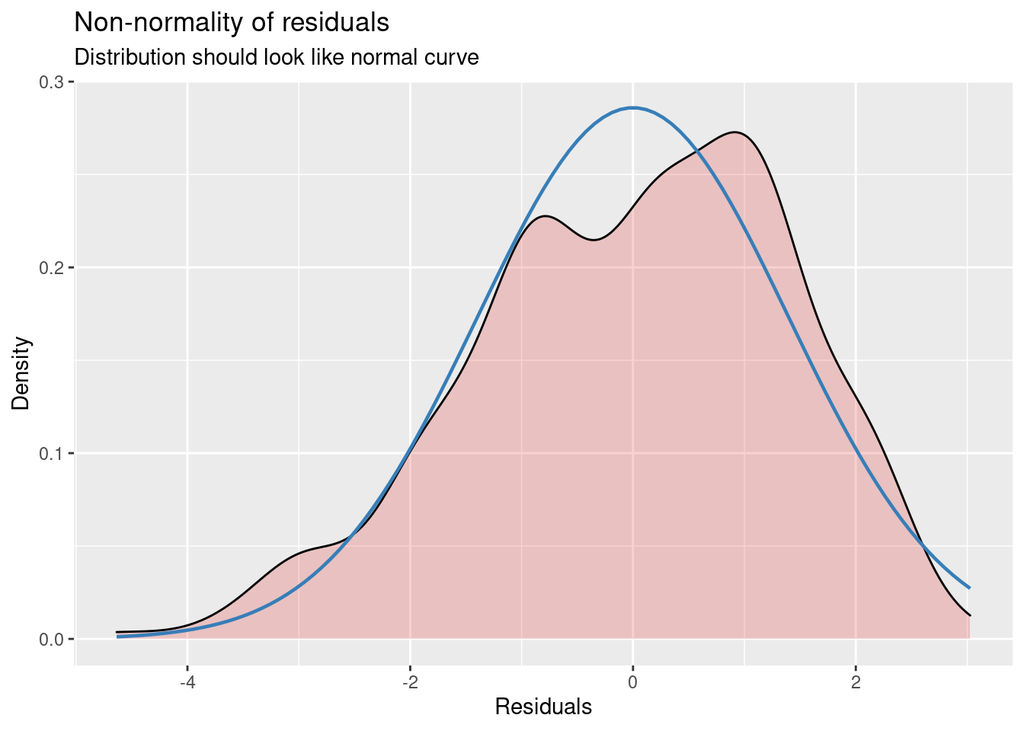

$~$ $~$

#### Model selection for Reccomendation

| Stepwise Model Path Analysis of Deviance Table |
| --- |
| Initial Model: |
| Reccomend ~ Priming * Product * Behav_enviro + Priming * Product * |
| Decision_mode + Priming * Product * Age |
| Final Model: |
| Reccomend ~ Priming + Product + Behav_enviro + Product:Behav_enviro |

Step

Df

Deviance

Resid. Df

Resid. Dev

AIC

276

695.6862

292.9436

- Priming:Product:Behav_enviro

1

0.0835636

277

695.7697

290.9791

- Priming:Behav_enviro

1

0.6660885

278

696.4358

289.2624

- Priming:Product:Decision_mode

2

7.1235589

280

703.5594

288.2747

- Priming:Decision_mode

2

0.3568128

282

703.9162

284.4247

- Product:Decision_mode

2

1.2190353

284

705.1352

280.9369

- Decision_mode

2

0.4742208

286

705.6094

277.1359

- Priming:Product:Age

1

3.5367000

287

709.1461

276.6158

- Priming:Product

1

0.2421164

288

709.3882

274.7169

- Product:Age

1

0.5307456

289

709.9190

272.9383

- Priming:Age

1

0.5051569

290

710.4241

271.1488

- Age

1

2.4973094

291

712.9215

270.1875

$~$ $~$

#### Reccomendation: Diagnostics Plots for linear model AFTER

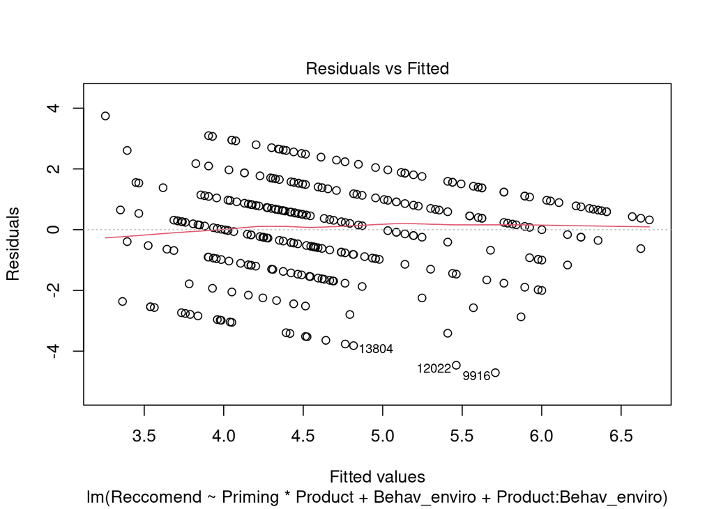

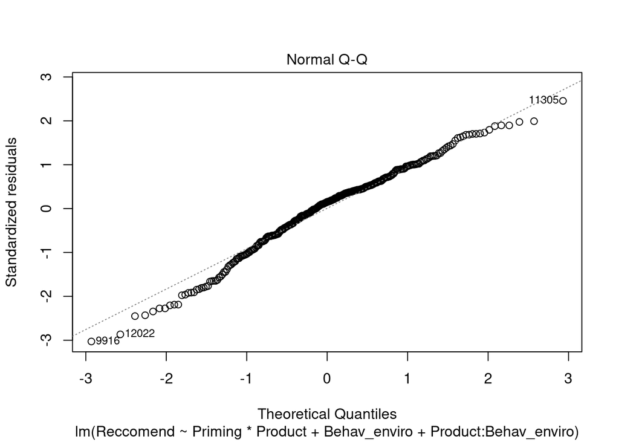

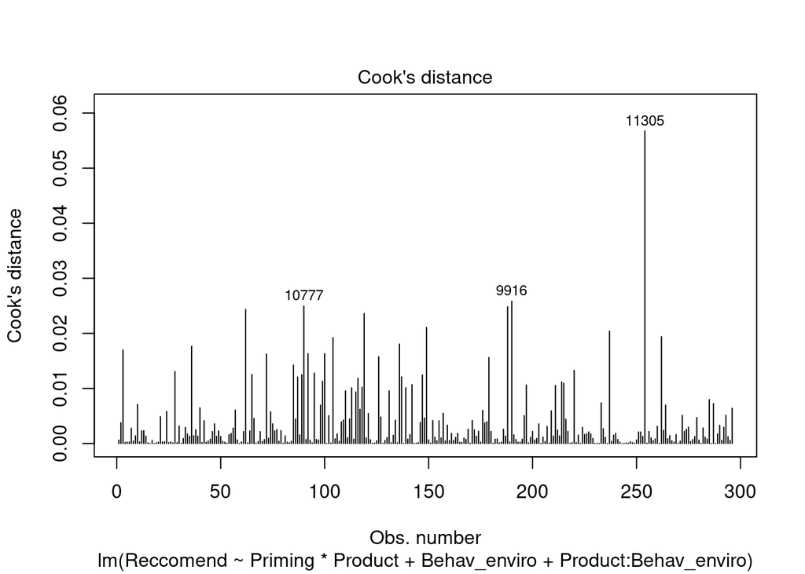

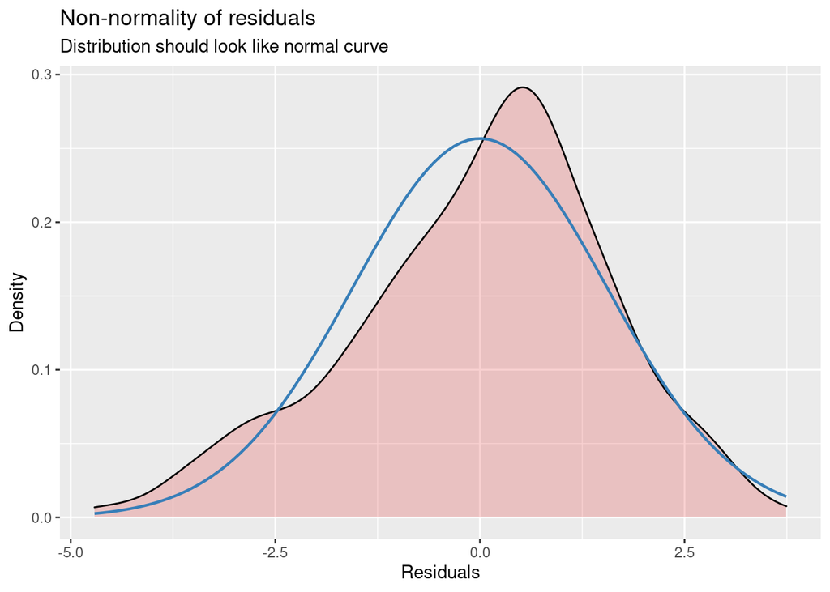

$~$ $~$

#### Model selection for Ecologic Evaluation

| Stepwise Model Path Analysis of Deviance Table |
| --- |
| Initial Model: |
| Ecolo_Eval ~ Priming * Product * Behav_enviro + Priming * Product * |
| Decision_mode + Priming * Product * Age |
| Final Model: |
| Ecolo_Eval ~ Priming + Product + Behav_enviro + Decision_mode + |
| Age + Priming:Product + Priming:Decision_mode + Product:Decision_mode + |
| Priming:Age + Product:Age + Priming:Product:Decision_mode + |
| Priming:Product:Age |

Step

Df

Deviance

Resid. Df

Resid. Dev

AIC

276

363.5980

100.88403

- Priming:Product:Behav_enviro

1

0.6434754

277

364.2414

99.40741

- Priming:Behav_enviro

1

1.1242200

278

365.3657

98.31960

- Product:Behav_enviro

1

1.4516272

279

366.8173

97.49330

$~$ $~$